# Exploring & Modeling MA Public School District Data

Zach Collester

##### Attempting to uncover potential biases within the MA public school system related to income and race, specifically with respect to college attendance rates.

```r
library(tidyverse)
library(ggpubr)
library(rstatix)
library(car)
library(moments)
library(readr)
library(Hmisc)
library(corrplot)
library(arsenal)
library(stringr)
library(summarytools)
```

## Cleaning the Data

First, I will save the row of state totals and then remove state totals from the dataframe. I am also removing `Hampden School District`, which had null values for all variables, and removing all districts with no 12th grade enrollment. Lastly, I am removing all technical districts, since these schools are theoretically serving a different population of interest and may skew the college attendance statistics. Also removing districts with null values for attending college.

```r
data <- read_csv("/Users/zacharycollester/Documents/ma_public_schools/data/csv_R/data.csv")
statetotals <- data.frame(data[407,])
data <- data[-c(407,408),]
data <- data %>% filter(G12 != 0)
data <- data %>% filter(str_detect(`District Name`, "Technical", negate=TRUE))
data <- data %>% filter(`Attending Coll./Univ. (%)` != 99999)
```

#### Null Data

Now I am summing the null data for each school district and plotting this data as a histogram.

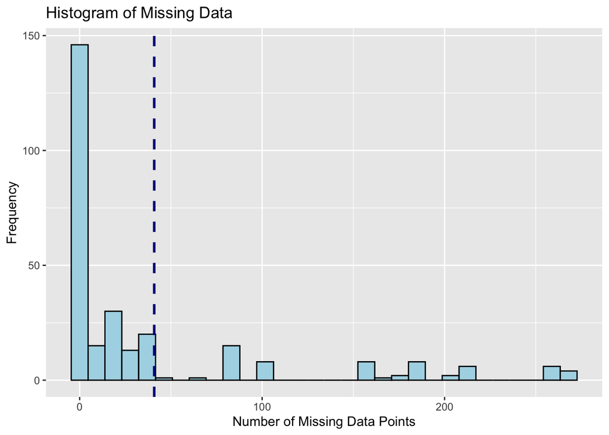

```r
nalist <- vector()
for (i in 1:ncol(data)){
  total <- sum(data[,i] == 99999)
  nalist[i] <- total
}
nalist <- data.frame(nalist)
missingdata <- ggplot(nalist, aes(x=nalist)) + geom_histogram(color="black", fill="lightblue") +
  geom_vline(aes(xintercept=mean(nalist)),color="darkblue", linetype="dashed", size=1) +
  labs(y="Frequency",x="Number of Missing Data Points") +
  ggtitle("Histogram of Missing Data")
missingdata
```

## College Attendance Rates and Enrollment

### Gradre 12 Enrollment

Below, I am plotting grade 12 student enrollment per district.

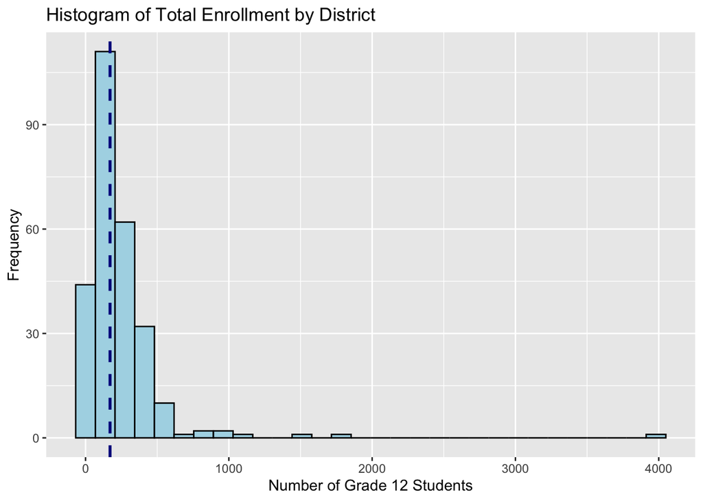

```r
enrollment <- vector()
for (i in 1:nrow(data)){
  enrollment[i] <- as.integer(data[i,"G12"])
}
enrollment <- data.frame(enrollment)
enrollmentdata <- ggplot(enrollment, aes(x=enrollment)) + geom_histogram(color="black", fill="lightblue") +
  geom_vline(aes(xintercept=median(enrollment)),color="darkblue", linetype="dashed", size=1) +
  labs(y="Frequency",x="Number of Grade 12 Students") +
  ggtitle("Histogram of Total Enrollment by District")
enrollmentdata
```

This is clearly a highly skewed histogram, showing that the majority of districts have fewer than 200 seniors. A few very large districts skew this histogram, specifically `Boston School District`, which has a total grade 12 enrollment of approximately 4,000 students. This may add bias into our analysis down the road, but we will come back to this later.

### Charter Schools

We are now going to add a column in the dataframe denoting whether a school is a charter school or not. We can then incoporate this binary grouping into visualizations later on.

```r
charter_bin <- str_detect(data$`District Name`, "Charter")
data$DistType <- "Public"
count = 0
for (i in 1:length(charter_bin)){
  if (charter_bin[i] == TRUE){
    data$DistType[i] <- "Charter"
    count = count + 1
  }
}
count
```

```
## [1] 37
```

```r
nrow(data)-count
```

```
## [1] 231
```

There are 37 charter districts and 231 non-charter districts in this dataset.